# Risk Analysis of Equity-Linked Insurance

Final Report

Peng Jin, Haoen Cui, Dayu Yao, Yuan Zhong, Wayne Tao

12/15/2017

### Variable Annuity Introduction

A variable annuity, like many other insurance products, is a contract between a policyholder and an insurance company, under which the policyholder agrees to make either a single purchase payment or a series of purchase payments. And the policyholder will receive a lump sum payment, annuitize accumulated asset base or begin taking regular withdrawals from sub-accounts. The premiums, or purchase payments from the policyholder are invested in a sub-account and the performance of this sub-account is linked in proportion to the ???uctuation of equity index or equity fund in which it invests. For this reason, variable annuities can also be called equity-linked insurance.

There are a wide range of variable annuity products on the market, our project is focused on the Guaranteed Minimum Death Benefit (GMDB). The GMDB is derived from some more basic insurance product such as traditional whole life insurance. Under traditional whole life insurance, a policyholder pays premium periodically (monthly, quarterly, semiannually, or annually), and a pre-determined death benefit goes to his beneficiary at the time of his death. The difference between GMDB and a traditional whole life insurance is that, for GMDB, the death benefit is generally equal to the greater of (a) a fixed amount specified on the contract or (b) premium payments invested in the market minus any prior withdrawals. The GMDB is attractive to both insurers and policyholders. The insurers could capture more capital gains in the stock market and the policyholders will keep up with the market to know their families will be protected against economic loss in the event of an untimely death.

To price the GMDB product, we need to consider the three sources of risk, decrement risk, investment risk and discount rate risk. We illustrate how the three sources of risk affect the premium on the graph below:

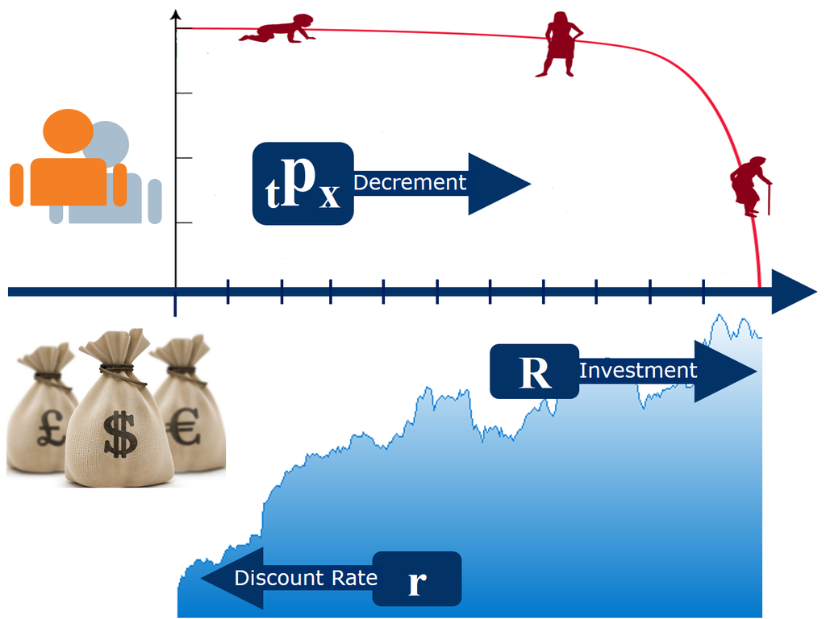

Variable Annuity Sources of Risks

At time zero, there is a group of policyholders. The insurance company will charge the premiums and invest the money into a sub-account which linked to a stock. As we move forward, the number of policyholders will decrease. We will need to evaluate the decrement risk and simulate the number of remaining policyholders each year. Also, as the policyholders die, we need to take money out of the account to pay the death benefit while the remaining amount will stay in the account. Secondly, we need to simulate the stock performance based on the investment mode. We denote “R” as the performance of the underlying stock on the graph, which is also the performance of the account. Lastly, we need to model the discount rate, denoted by “r”, to discount back the future cash flow. With the discount rate model, the insurance company can calculate the account value at each point on the timeline. Therefore, the insurers will be able to apply different premium principle to model the premium they need to charge to individual policyholders.

### Models: Mortality Decrement

In this project, we primarily concern about the risk of mortality under this source of risk. Let’s define (x) as a life age at x, $T_{(x)}$ as the remaining life time random variable of (x), and $\mathbb{P}(T_{(x)}>t)$as the probability that a life (x) survive and extra t years, which can also be denoted by $_{t}p_{x}$. To simulate the future life time of a policyholder, we need the continuous survival function. Once we have the continuous survival function, we could get the CDF and PDF. Then, we could apply the methods, such as inverse transformation and Accept-Reject. We will use a Life table to estimate the survival function. Below is a sample of Life Table:

| x | $l_{x}$ | $d_{x}$ |
| --- | --- | --- |
| 0 | 100000 | 637 |
| 1 | 99363 | 45 |
| 2 | 99318 | 28 |

$l_x$ is the number of survivors at age x, and $d_x$ is the number of deaths during age x. The formula for the estimator for integral ages is $\widehat{_{t}p_x} = \frac{l_{x+t}}{l_x}$. Since Life Table is a discretized continuous model, we could use UDD assumption for fractional ages, which is to apply linear interpolation for fractional ages. Finally, we have a continuous survival model for any fractional age.

### Model: Equity Investment Return

The equity investment return can be modeled in many different ways. First we need some period of historical stock performance data, which we can use to estimate the parameters and predict future return of that particular stock. Typically, Brownian Motion (both arithmetic and geometric) and time series forecasting methods (ARIMA, auto-regressive) are ways to help achieve this goal. In this project, we used geometric Brownian motion to stimulate future stock prices; however, we hope to complete the inventory in the future.

A geometric Brownian motion is a continuous stochastic process in which the logarithm of the randomly varying quantity follows a Brownian motion with drift. (from Wikipedia) It satisfies the following stochastic differential equation.

$$\frac{dS_t}{S_t}=\mu dt+\sigma dW_t$$

$\mu$ represents the percentage drift and $\sigma$ represents the percentage volatility. This basically means that after infinitesimal time $dt$, the price $dS_t$ equals to $S_t$ times the drift and volatility factor. Solving this equation , we get:

$$\frac{S_t}{S_0} \sim lgnorm(\mu-\frac{1}{2}\sigma^2,\sigma)$$
In our case, $S_0$ denotes the last stock closing price of the training data and $S_t$ denotes the predicted stock closing price after t periods. The solution of the SDE indicates the $\frac{S_t}{S_0}$ follows a log-normal distribution.

The code for this model is structured into four functions, all of which has their own functionality. The first function is `risk.clean.data`. This function acquires data through `getSymbols` function in the `quantmod` package and make sure it is ready for analysis. The Second function is called `risk.calibrate`. This function estimates the log-normal parameters. The third function is `risk.predict`. By utilizing previous parameters and random number generating method(`rnorm`), we created a matrix containing multiple predicted stock path values. The fourth part is a plotting function called `risk.plot`. This function helps to visualize the stock paths by shading the confidence intervals and plotting the median and mean of the stock paths.

Below is a sample output when all the functions are run:

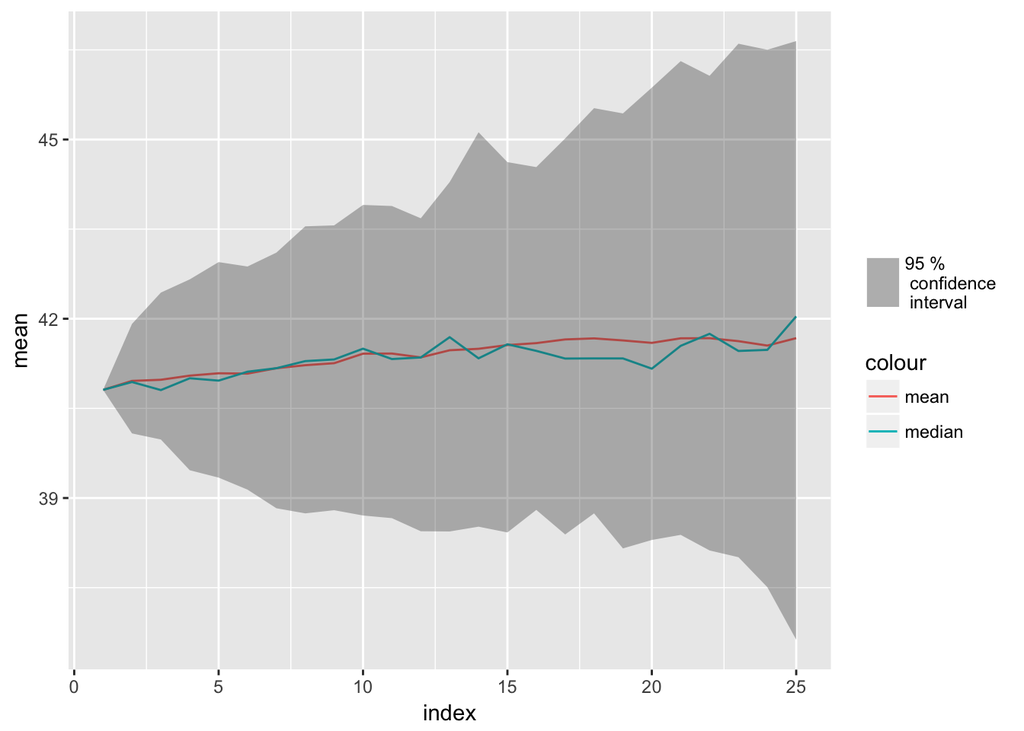

### Model: (Risk-free) Discount Rate

Just like the Equity Investment Return, there are a lot of models which we can utilize to predict future interest rate risk. Vasicek, Black-Derman-Toy, and Cox-Ingersoll-Ross are all very good models that can help us predict the future projection of interest rates. However, again, due to time constraints, we only built one interest rate model featuring the classic Vasicek model.

Vasicek Short Rate Model is a mathematical model describing the evolution of interest rates. (from Wikipedia) The model specifies the instantaneous interest rate follows stochastic differential equation shown below:

$$dr_t=a(b-r_t)dt+\sigma dW_t$$

solving the SDE, we can get that $\mathbb{E}[r_t]=r_0e^{-at}+b(1-e^{-at}), \space \space Var[r_t] = \frac{\sigma^2}{2a}(1-e^{-2at})$

Similar to the simulations of stock paths, we used the same methodologies. The code can be break down into the following parts: `disc.clean.data`, `disc.calibrate`, `disc.predict`, `disc.simulate.vasicek.helper`, `disc.simulate.vasicek,disc.predict.vasicek`, `disc.predict.vasicek.ZCBondPrice`, `disc.predict.vasicek.YieldCurve`, and `disc.plot`.

`disc.clean.data` is used to clean data pulled from getSymbol for following analysis.

`disc.calibrate` is used to calibrate a model using data provided.

`disc.predict` is used to predict future discount factor based on the fitted model

`disc.simulate.vasicek.helper` is a helper function that calculates the next rate based on the discretization of the Vasicek model.

`disc.simulate.vasicek` is used to generate a single short rate simulation using the Vasicek model.

`disc.predict.vasicek` is used to generate several short rate simulations using the Vasicek model.

`disc.plot` is used to plot historic data and predictions.

- The inverse CDF generator takes a sample size of n and an inverse CDF function, and then returns a vector of identical independent distributed sample of length n.
- The accept-reject generator takes a sample size of n, three functions of target and proposal distribution (dtarget, dproposal and rproposal) and a normalizeing constant. The dtarget function is the density function of target distribution. The dproposal function is the density function of proposal distribution. The rproposal function is the random number generator of proposal distribution. The normalizing constant, C, is defaulted “auto”. If C’s value is auto, another function that calculate the value of normalizing constant is called. The accept-reject generator returns a list consisting of the vector of generated identical independent distributed sample and the number of rejections before reaching the sample size desired.
- Similar to accept-reject method, the Metropolis-Hasting generator takes number of sample size, three functions of target and proposal distribution and an additional parameter: x.init, the initial point of the chain. X.int is defaulted as NA. If it’s not specified, rproposal(n, param) must have default param value. The Metropolis-Hasting generator generates a list consisting of a vector of identical independent distributed sample of length n and the number of rejections before reaching the sample size.

```r
x <- STAT428.random.number.1D(n = n*N,
                                method = "inverseCDF",
                                 method.param =
                                  list(
                                    invCDF =
                                      compiler::cmpfun(function(p)
                                        model.fit$tqx.inv(p, start.age, gender))))
  # u <- runif(n*N)
  # x <- model.fit$tqx.inv(u, x = start.age, sex = gender)
```

```r
inv.calibrate <- function (hist.data, model) {
  if(model=="GBM"){
    n <- nrow(hist.data) #sample size
    return <- numeric(n) #storage for replicates
    for(i in 1:n-1){
      return[i] <- as.numeric(hist.data[i+1])/as.numeric(hist.data[i])
    }
    return <- return[-which(return == 0)]
    param <- as.numeric(fitdistrplus::fitdist(return, distr = "lnorm", method = "mle")$estimate)
    return(param)
  }
}
```

```r
risk.calibrate <- function (data, model = "GBM"){
  if(model=='GBM'){
    n <- nrow(data) #sample size
    return <- numeric(n) #storage for replicates
    for(i in 1:n-1){
      return[i] <- as.numeric(data[i+1])/as.numeric(data[i])
    }
    return <- return[-which(return == 0)]
    param <- as.numeric(fitdistrplus::fitdist(return, distr = 'lnorm', method = 'mle')$estimate)
    return(param)
  }
}
```

###Data Source

####Mortality Table Data The data was downloaded from The Human Mortality Database, a nonprofit organization that provides mortality data for researchers, students, and policy analysts. There are 39 countries’ data available on the website, but this project is mainly focused on the USA.

####Stock and Interest Rate Data These data are acquired through real time downloading mechanisms established by the `quanmod` package. We can specify what kind of financial data, what time interval, and what data source, then the data is automatically pulled from the designated source and a xts object is generated for our analysis.